# Assignment n.7

Variable selection

2025-04-09

### **The *Hitters* Data**

This dataset is part of the R-package ISLR2 and contains certain statistics and salaries of major league baseball players for the years 1986–87. We wish to predict a baseball player’s `Salary` on the basis of various statistics associated with performance. It consists of 20 variables and 322 observations, only the `Salary` variable has missing observations. The definitions of the variables of the dataset are as follows:

-`AtBat`: Number of shots made with a baseball bat during the 1986–1987 season,

-`Hits`: Number of hits made in the 1986–1987 season,

-`HmRun`: Most valuable hits in the 1986–1987 season,

-`Runs`: The points he earned for his team in the 1986–1987 season,

-`RBI`: Number of players a batsman had jogged when he hit in the season,

-`Walks`: Number of mistakes made by the opposing player,

-`Years`: Player’s playing time in major league (in year),

-`CAtBat`: Number of shots made with a baseball bat in career,

-`CHits`: Number of hits made in the career,

-`CHmRun`: Most valuable hits in the career,

-`CRuns`: The points he earned for his team in his career,

-`CRBI`: Number of players a batsman had jogged when he hit in the career,

-`CWalks`: Number of mistakes made by the opposing player in career,

-`League`: A factor with A and N levels showing the league in which the player played until the end of the season,

-`Division`: A factor with levels E and W indicating the position played by the player at the end of 1986,

-`PutOuts`: Helping your teammate in-game,

-`Assists`: Number of assists made by the player in the 1986–1987 season,

-`Errors`: Player’s errors in the 1986–1987 season,

-`Salary`: The salary of the player in the 1986–1987 season (in thousand),

-`NewLeague`: A factor with A and N levels showing the player’s league at the start of the 1987 season.

```r
library(ISLR2)
names(Hitters)
```

```
##  [1] "AtBat"     "Hits"      "HmRun"     "Runs"      "RBI"       "Walks"
##  [7] "Years"     "CAtBat"    "CHits"     "CHmRun"    "CRuns"     "CRBI"
## [13] "CWalks"    "League"    "Division"  "PutOuts"   "Assists"   "Errors"
## [19] "Salary"    "NewLeague"
```

```r
dim(Hitters)
```

```
## [1] 322  20
```

```r
sum(is.na(Hitters$Salary))
```

```
## [1] 59
```

First of all, we note that the `Salary` variable is missing for some of the players. The `is.na()` function can be used to identify the missing observations. It returns a vector of the same length as the input vector, with a `TRUE` for any elements that are missing, and a `FALSE` for non-missing elements. The `sum()` function can then be used to count all of the missing elements.

Hence we see that `Salary` is missing for 59 players. The `na.omit()` function removes all of the rows that have missing values in any variable.

```r
Hitters <- na.omit(Hitters)
dim(Hitters)
```

```
## [1] 263  20
```

```r
sum(is.na(Hitters))
```

```
## [1] 0
```

### Best Subset Selection

Here we apply the best subset selection approach to the `Hitters` data.

The `regsubsets()` function (part of the `leaps` library) performs best subset selection by identifying the best model that contains a given number of predictors, where *best* is quantified using RSS. The syntax is the same as for `lm()`. The `summary()` command outputs the best set of variables for each model size.

```r
library(leaps)
regfit.full <- regsubsets(Salary ~ ., data = Hitters)
reg.summary <- summary(regfit.full)
reg.summary$outmat
```

```
##          AtBat Hits HmRun Runs RBI Walks Years CAtBat CHits CHmRun CRuns CRBI
## 1  ( 1 ) " "   " "  " "   " "  " " " "   " "   " "    " "   " "    " "   "*"
## 2  ( 1 ) " "   "*"  " "   " "  " " " "   " "   " "    " "   " "    " "   "*"
## 3  ( 1 ) " "   "*"  " "   " "  " " " "   " "   " "    " "   " "    " "   "*"
## 4  ( 1 ) " "   "*"  " "   " "  " " " "   " "   " "    " "   " "    " "   "*"
## 5  ( 1 ) "*"   "*"  " "   " "  " " " "   " "   " "    " "   " "    " "   "*"
## 6  ( 1 ) "*"   "*"  " "   " "  " " "*"   " "   " "    " "   " "    " "   "*"
## 7  ( 1 ) " "   "*"  " "   " "  " " "*"   " "   "*"    "*"   "*"    " "   " "
## 8  ( 1 ) "*"   "*"  " "   " "  " " "*"   " "   " "    " "   "*"    "*"   " "
##          CWalks LeagueN DivisionW PutOuts Assists Errors NewLeagueN
## 1  ( 1 ) " "    " "     " "       " "     " "     " "    " "
## 2  ( 1 ) " "    " "     " "       " "     " "     " "    " "
## 3  ( 1 ) " "    " "     " "       "*"     " "     " "    " "
## 4  ( 1 ) " "    " "     "*"       "*"     " "     " "    " "
## 5  ( 1 ) " "    " "     "*"       "*"     " "     " "    " "
## 6  ( 1 ) " "    " "     "*"       "*"     " "     " "    " "
## 7  ( 1 ) " "    " "     "*"       "*"     " "     " "    " "
## 8  ( 1 ) "*"    " "     "*"       "*"     " "     " "    " "
```

An asterisk indicates that a given variable is included in the corresponding model. For instance, this output indicates that the best two-variable model contains only `Hits` and `CRBI`. By default, `regsubsets()` only reports results up to the best eight-variable model. But the `nvmax` option can be used in order to return as many variables as are desired. Here we fit up to a 19-variable model.

```r
regfit.full <- regsubsets(Salary ~ ., data = Hitters, nvmax = 19)
reg.summary <- summary(regfit.full)
```

The `summary()` function also returns $R^2$, RSS, adjusted $R^2$, $C_p$, and BIC. We can examine these to try to select the *best* overall model.

```r
names(reg.summary)
```

```
## [1] "which"  "rsq"    "rss"    "adjr2"  "cp"     "bic"    "outmat" "obj"
```

For instance, we see that the $R^2$ statistic increases from $32 \%$, when only one variable is included in the model, to almost $55 \%$, when all variables are included. As expected, the $R^2$ statistic increases monotonically as more variables are included.

```r
reg.summary$rsq
```

```
##  [1] 0.3214501 0.4252237 0.4514294 0.4754067 0.4908036 0.5087146 0.5141227
##  [8] 0.5285569 0.5346124 0.5404950 0.5426153 0.5436302 0.5444570 0.5452164
## [15] 0.5454692 0.5457656 0.5459518 0.5460945 0.5461159
```

Plotting RSS, adjusted $R^2$, $C_p$, and BIC for all of the models at once will help us decide which model to select. Note the `type = "l"` option tells `R` to connect the plotted points with lines.

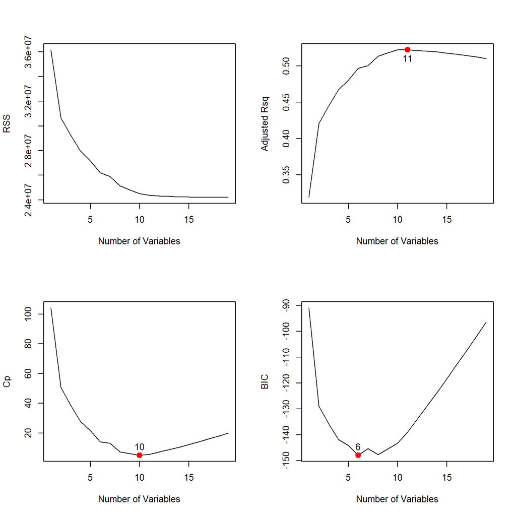

```r
par(mfrow=c(2,2))

# residual sum of squares
plot(reg.summary$rss,xlab="Number of Variables",ylab="RSS",type="l")

# adjusted-R^2 with its largest value
plot(reg.summary$adjr2,xlab="Number of Variables",ylab="Adjusted Rsq",type="l")
i <- which.max(reg.summary$adjr2)
points(i,reg.summary$adjr2[i], col="red",cex=2,pch=20)
text(i,reg.summary$adjr2[i], i, pos=1)

# Mallow's Cp with its smallest value
plot(reg.summary$cp,xlab="Number of Variables",ylab="Cp",type='l')
i <- which.min(reg.summary$cp)
points(i,reg.summary$cp[i],col="red",cex=2,pch=20)
text(i,reg.summary$cp[i], i, pos=3)

# BIC with its smallest value
plot(reg.summary$bic,xlab="Number of Variables",ylab="BIC",type='l')
i <- which.min(reg.summary$bic)
points(i,reg.summary$bic[i],col="red",cex=2,pch=20)
text(i,reg.summary$bic[i], i, pos=3)
```

```r
par(mfrow=c(1,1))
```

The `points()` command works like the `plot()` command, except that it puts points on a plot that has already been created, instead of creating a new plot. The `which.max()` function can be used to identify the location of the maximum point of a vector. We will now plot a red dot to indicate the model with the largest adjusted $R^2$ statistic. The `text()` command adds a text in a specified position, in this case the number of predictors of the best model.

The `regsubsets()` function has a built-in `plot()` command which can be used to display the selected variables for the best model with a given number of predictors, ranked according to the BIC, $C_p$, adjusted $R^2$, or AIC. To find out more about this function, type `?plot.regsubsets`.

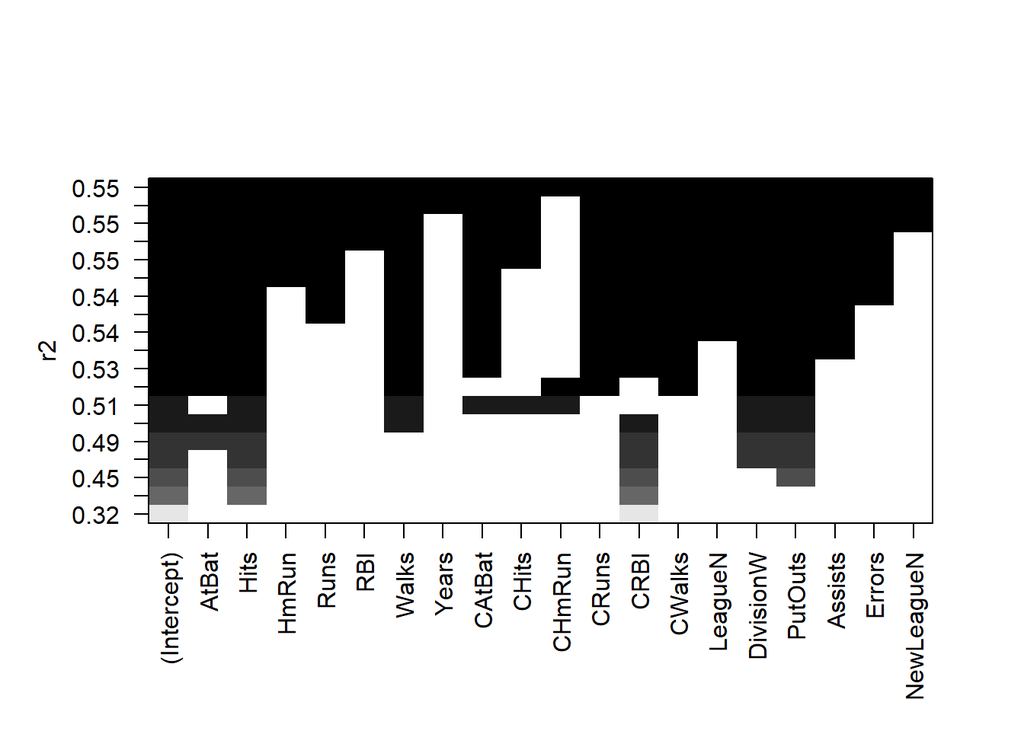

```r
plot(regfit.full, scale = "r2")
```

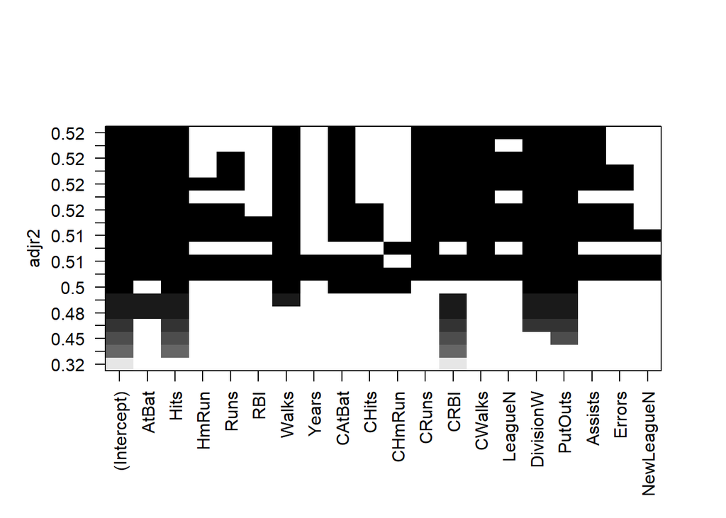

```r
plot(regfit.full, scale = "adjr2")
```

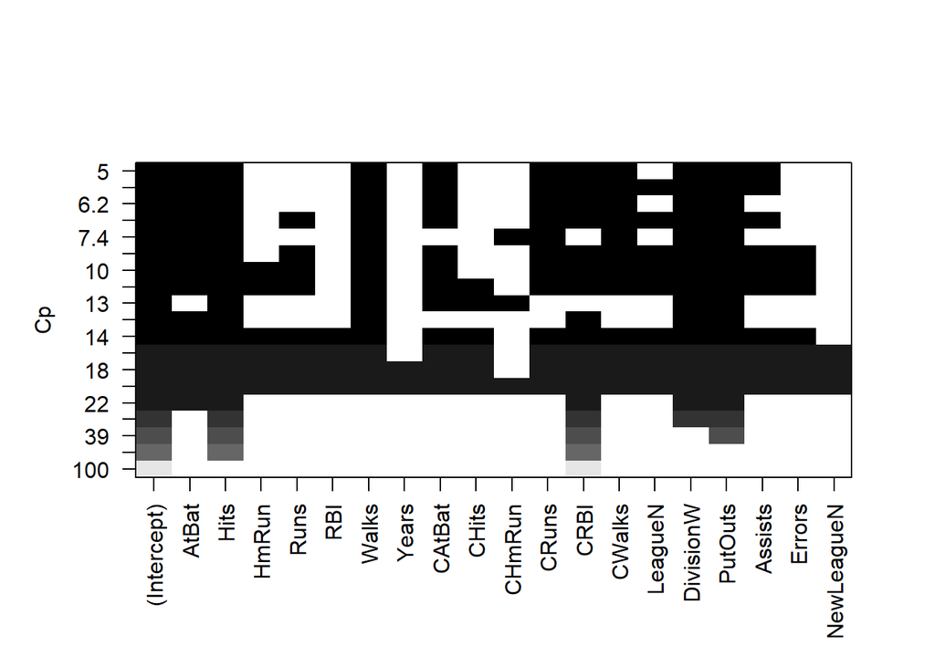

```r
plot(regfit.full, scale = "Cp")
```

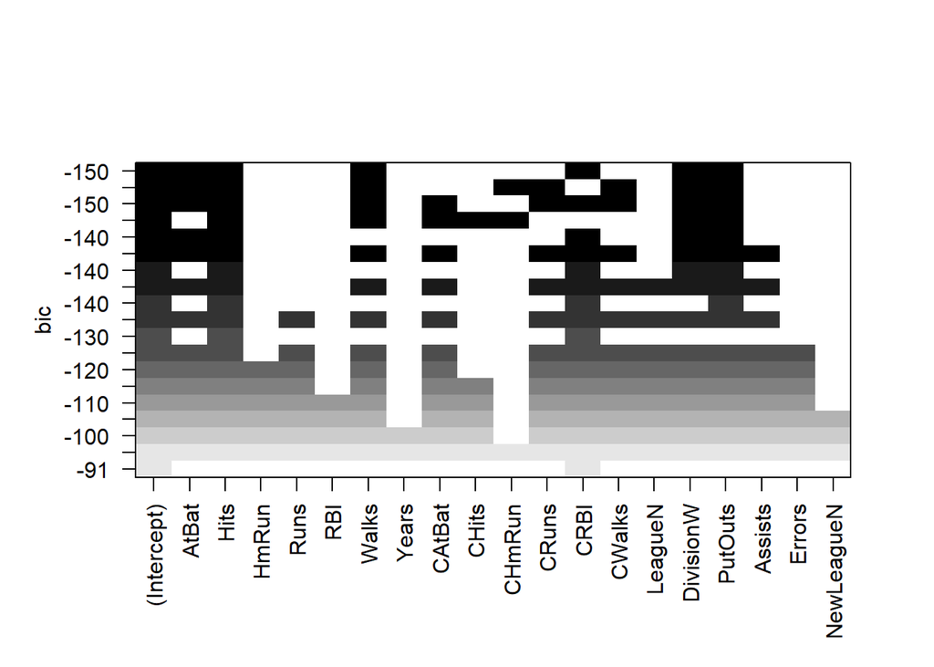

```r
plot(regfit.full, scale = "bic")
```

The top row of each plot contains a black square for each variable selected according to the optimal model associated with that statistic. For instance, we see that several models share a BIC close to $-150$. However, the model with the lowest BIC is the six-variable model that contains only `AtBat`, `Hits`, `Walks`, `CRBI`, `DivisionW`, and `PutOuts`. We can use the `coef()` function to see the coefficient estimates associated with this model.

```r
coef(regfit.full, 6)
```

```
##  (Intercept)        AtBat         Hits        Walks         CRBI    DivisionW
##   91.5117981   -1.8685892    7.6043976    3.6976468    0.6430169 -122.9515338
##      PutOuts
##    0.2643076
```

More details on the selected models can be obtained by fitting it with the `lm()` function. This requires the model formula that can be either written explicitly as in,

```r
lm.fit <- lm(Salary ~ AtBat+Hits+Walks+CRBI+Division+PutOuts, data = Hitters)
summary(lm.fit)
```

```
##
## Call:
## lm(formula = Salary ~ AtBat + Hits + Walks + CRBI + Division +
##     PutOuts, data = Hitters)
##
## Residuals:
##     Min      1Q  Median      3Q     Max
## -873.11 -181.72  -25.91  141.77 2040.47
##
## Coefficients:
##               Estimate Std. Error t value Pr(>|t|)
## (Intercept)   91.51180   65.00006   1.408 0.160382
## AtBat         -1.86859    0.52742  -3.543 0.000470 ***
## Hits           7.60440    1.66254   4.574 7.46e-06 ***
## Walks          3.69765    1.21036   3.055 0.002488 **
## CRBI           0.64302    0.06443   9.979  < 2e-16 ***
## DivisionW   -122.95153   39.82029  -3.088 0.002239 **
## PutOuts        0.26431    0.07477   3.535 0.000484 ***
## ---
## Signif. codes:  0 '***' 0.001 '**' 0.01 '*' 0.05 '.' 0.1 ' ' 1
##
## Residual standard error: 319.9 on 256 degrees of freedom
## Multiple R-squared:  0.5087, Adjusted R-squared:  0.4972
## F-statistic: 44.18 on 6 and 256 DF,  p-value: < 2.2e-16
```

but this is inefficient, or it can be recovered from the available object. In fact, this is not straightforward, but it can be done with the following steps. Firstly, we obtain a vector with the the names of all the possible predictors, that is of all the variables with the exclusion of the response `Salary`,

```r
var.names <- names(Hitters)
pred.names <- var.names[var.names!="Salary"]
pred.names
```

```
##  [1] "AtBat"     "Hits"      "HmRun"     "Runs"      "RBI"       "Walks"
##  [7] "Years"     "CAtBat"    "CHits"     "CHmRun"    "CRuns"     "CRBI"
## [13] "CWalks"    "League"    "Division"  "PutOuts"   "Assists"   "Errors"
## [19] "NewLeague"
```

secondly, we obtain the logical vector that identifies the predictors of the required model that, in this example, is the model selected by BIC with 6 predictors,

```r
is.in.selected <- reg.summary$which[6,]
is.in.selected
```

```
## (Intercept)       AtBat        Hits       HmRun        Runs         RBI
##        TRUE        TRUE        TRUE       FALSE       FALSE       FALSE
##       Walks       Years      CAtBat       CHits      CHmRun       CRuns
##        TRUE       FALSE       FALSE       FALSE       FALSE       FALSE
##        CRBI      CWalks     LeagueN   DivisionW     PutOuts     Assists
##        TRUE       FALSE       FALSE        TRUE        TRUE       FALSE
##      Errors  NewLeagueN
##       FALSE       FALSE
```

so that we can obtain a vector with the names of the predictors included in the model as (note that we use the index “-1” to remove the entry corresponding to the intercept)

```r
pred.names[is.in.selected[-1]]
```

```
## [1] "AtBat"    "Hits"     "Walks"    "CRBI"     "Division" "PutOuts"
```

finally, we can construct the character string with the model formula by applying the function `paste()`. To find out more about this function, type `?paste`.

```r
model.formula <- paste(pred.names[is.in.selected], collapse="+")
model.formula
```

```
## [1] "AtBat+Hits+HmRun+Years+CWalks+PutOuts+Assists"
```

```r
model.formula <- paste("Salary", "~", model.formula)
model.formula
```

```
## [1] "Salary ~ AtBat+Hits+HmRun+Years+CWalks+PutOuts+Assists"
```

```r
lm.fit <- lm(model.formula, data = Hitters)
```

This operation can be more efficiently implemented in a function that we call `make.formula()`.

```r
# response    = character string with the name of the response
# var.names   = character vector with all the variable names
# out.summary = output of summary() when applied to a "regsubset" object
# idx         = index of the required model
# resp.trans  = required transformation of the response

make.formula <- function(response, var.names, out.summary, idx, resp.trans =NULL){
  is.in.selected <- out.summary$which[idx,]
  pred.names     <- var.names[var.names!=response]
  predictors     <- pred.names[is.in.selected[-1]]
  model.f        <- paste(predictors, collapse="+")
  if(!is.null(resp.trans)) response <- resp.trans
  model.f        <- paste(response, "~", model.f)
  return(model.f)
}

# examples

model.formula <- make.formula("Salary", names(Hitters), reg.summary, 6)
model.formula
```

```
## [1] "Salary ~ AtBat+Hits+Walks+CRBI+Division+PutOuts"
```

```r
model.formula <- make.formula("Salary", names(Hitters), reg.summary, 6, "log(Salary)")
model.formula
```

```
## [1] "log(Salary) ~ AtBat+Hits+Walks+CRBI+Division+PutOuts"
```

### Forward and Backward Stepwise Selection

We can also use the `regsubsets()` function to perform forward stepwise or backward stepwise selection, using the argument `method = "forward"` or `method = "backward"`.

```r
regfit.fwd <- regsubsets(Salary ~ ., data = Hitters, nvmax = 19, method = "forward")
summary(regfit.fwd)$outmat
```

```
##           AtBat Hits HmRun Runs RBI Walks Years CAtBat CHits CHmRun CRuns CRBI
## 1  ( 1 )  " "   " "  " "   " "  " " " "   " "   " "    " "   " "    " "   "*"
## 2  ( 1 )  " "   "*"  " "   " "  " " " "   " "   " "    " "   " "    " "   "*"
## 3  ( 1 )  " "   "*"  " "   " "  " " " "   " "   " "    " "   " "    " "   "*"
## 4  ( 1 )  " "   "*"  " "   " "  " " " "   " "   " "    " "   " "    " "   "*"
## 5  ( 1 )  "*"   "*"  " "   " "  " " " "   " "   " "    " "   " "    " "   "*"
## 6  ( 1 )  "*"   "*"  " "   " "  " " "*"   " "   " "    " "   " "    " "   "*"
## 7  ( 1 )  "*"   "*"  " "   " "  " " "*"   " "   " "    " "   " "    " "   "*"
## 8  ( 1 )  "*"   "*"  " "   " "  " " "*"   " "   " "    " "   " "    "*"   "*"
## 9  ( 1 )  "*"   "*"  " "   " "  " " "*"   " "   "*"    " "   " "    "*"   "*"
## 10  ( 1 ) "*"   "*"  " "   " "  " " "*"   " "   "*"    " "   " "    "*"   "*"
## 11  ( 1 ) "*"   "*"  " "   " "  " " "*"   " "   "*"    " "   " "    "*"   "*"
## 12  ( 1 ) "*"   "*"  " "   "*"  " " "*"   " "   "*"    " "   " "    "*"   "*"
## 13  ( 1 ) "*"   "*"  " "   "*"  " " "*"   " "   "*"    " "   " "    "*"   "*"
## 14  ( 1 ) "*"   "*"  "*"   "*"  " " "*"   " "   "*"    " "   " "    "*"   "*"
```

[output cut: 25 more lines]

```r
regfit.bwd <- regsubsets(Salary ~ ., data = Hitters, nvmax = 19, method = "backward")
summary(regfit.bwd)$outmat
```

```
##           AtBat Hits HmRun Runs RBI Walks Years CAtBat CHits CHmRun CRuns CRBI
## 1  ( 1 )  " "   " "  " "   " "  " " " "   " "   " "    " "   " "    "*"   " "
## 2  ( 1 )  " "   "*"  " "   " "  " " " "   " "   " "    " "   " "    "*"   " "
## 3  ( 1 )  " "   "*"  " "   " "  " " " "   " "   " "    " "   " "    "*"   " "
## 4  ( 1 )  "*"   "*"  " "   " "  " " " "   " "   " "    " "   " "    "*"   " "
## 5  ( 1 )  "*"   "*"  " "   " "  " " "*"   " "   " "    " "   " "    "*"   " "
## 6  ( 1 )  "*"   "*"  " "   " "  " " "*"   " "   " "    " "   " "    "*"   " "
## 7  ( 1 )  "*"   "*"  " "   " "  " " "*"   " "   " "    " "   " "    "*"   " "
## 8  ( 1 )  "*"   "*"  " "   " "  " " "*"   " "   " "    " "   " "    "*"   "*"
## 9  ( 1 )  "*"   "*"  " "   " "  " " "*"   " "   "*"    " "   " "    "*"   "*"
## 10  ( 1 ) "*"   "*"  " "   " "  " " "*"   " "   "*"    " "   " "    "*"   "*"
## 11  ( 1 ) "*"   "*"  " "   " "  " " "*"   " "   "*"    " "   " "    "*"   "*"
## 12  ( 1 ) "*"   "*"  " "   "*"  " " "*"   " "   "*"    " "   " "    "*"   "*"
## 13  ( 1 ) "*"   "*"  " "   "*"  " " "*"   " "   "*"    " "   " "    "*"   "*"
## 14  ( 1 ) "*"   "*"  "*"   "*"  " " "*"   " "   "*"    " "   " "    "*"   "*"
```

[output cut: 25 more lines]

For instance, we see that using forward stepwise selection, the best one-variable model contains only `CRBI`, and the best two-variable model additionally includes `Hits`. For this data, the best one-variable through six-variable models are each identical for best subset and forward selection. However, the best seven-variable models identified by forward stepwise selection, backward stepwise selection, and best subset selection are different.

```r
coef(regfit.full, 7)
```

```
##  (Intercept)         Hits        Walks       CAtBat        CHits       CHmRun
##   79.4509472    1.2833513    3.2274264   -0.3752350    1.4957073    1.4420538
##    DivisionW      PutOuts
## -129.9866432    0.2366813
```

```r
coef(regfit.fwd, 7)
```

```
##  (Intercept)        AtBat         Hits        Walks         CRBI       CWalks
##  109.7873062   -1.9588851    7.4498772    4.9131401    0.8537622   -0.3053070
##    DivisionW      PutOuts
## -127.1223928    0.2533404
```

```r
coef(regfit.bwd, 7)
```

```
##  (Intercept)        AtBat         Hits        Walks        CRuns       CWalks
##  105.6487488   -1.9762838    6.7574914    6.0558691    1.1293095   -0.7163346
##    DivisionW      PutOuts
## -116.1692169    0.3028847
```

##### 1. **Apply Best Subset Selection, identify the best model according to BIC, fit the selected model and use the function `summary()` to summarise its properties.**

```r
regfit.full <- regsubsets(Salary ~ ., data = Hitters, nvmax = 19)
reg.summary <- summary(regfit.full)
i <- which.min(reg.summary$bic)
i
```

```
## [1] 6
```

```r
coef(regfit.full, i)
```

```
##  (Intercept)        AtBat         Hits        Walks         CRBI    DivisionW
##   91.5117981   -1.8685892    7.6043976    3.6976468    0.6430169 -122.9515338
##      PutOuts
##    0.2643076
```

```r
model.formula <- make.formula("Salary", names(Hitters), reg.summary, i)
model.formula
```

```
## [1] "Salary ~ AtBat+Hits+Walks+CRBI+Division+PutOuts"
```

```r
best.bic <- lm(model.formula, data=Hitters)
summary(best.bic)
```

```
##
## Call:
## lm(formula = model.formula, data = Hitters)
##
## Residuals:
##     Min      1Q  Median      3Q     Max
## -873.11 -181.72  -25.91  141.77 2040.47
##
## Coefficients:
##               Estimate Std. Error t value Pr(>|t|)
## (Intercept)   91.51180   65.00006   1.408 0.160382
## AtBat         -1.86859    0.52742  -3.543 0.000470 ***
## Hits           7.60440    1.66254   4.574 7.46e-06 ***
## Walks          3.69765    1.21036   3.055 0.002488 **
## CRBI           0.64302    0.06443   9.979  < 2e-16 ***
## DivisionW   -122.95153   39.82029  -3.088 0.002239 **
## PutOuts        0.26431    0.07477   3.535 0.000484 ***
## ---
## Signif. codes:  0 '***' 0.001 '**' 0.01 '*' 0.05 '.' 0.1 ' ' 1
##
## Residual standard error: 319.9 on 256 degrees of freedom
## Multiple R-squared:  0.5087, Adjusted R-squared:  0.4972
## F-statistic: 44.18 on 6 and 256 DF,  p-value: < 2.2e-16
```

We can see that the coefficients of all the selected variables are significantly different to zero. Note also that the $R^2$ statistics takes value 0.51 whereas for the full model $R^2$=0.55.

```r
reg.summary$rsq
```

```
##  [1] 0.3214501 0.4252237 0.4514294 0.4754067 0.4908036 0.5087146 0.5141227
##  [8] 0.5285569 0.5346124 0.5404950 0.5426153 0.5436302 0.5444570 0.5452164
## [15] 0.5454692 0.5457656 0.5459518 0.5460945 0.5461159
```

##### 2. **Carry out a dignostic check of the selected model.**

The diagnostic plots show the a residual nonlinear component is present, and also the homoscedasticity assumption does not seem to be satisfied. There also seem to be some outliers and high-leverage points, that we do not consider for the moment.

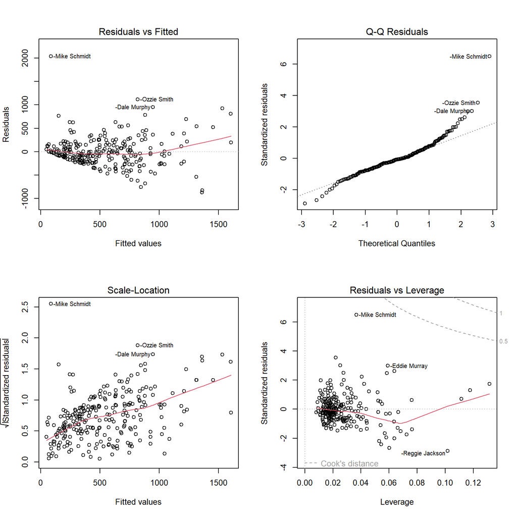

```r
par(mfrow=c(2,2))
plot(best.bic)
```

```r
par(mfrow=c(1,1))
```

##### 3. **Apply a log-transform of the response variable, select the best model according to BIC and carry out a diagnostic analysis of the resulting model.**

We note that the selected model has only 3 covariates, including the variable `Years` that was not present in the previous selected model. Despite the reduction in the number of variables, the $R^2$ statistic is almost unchanged.

```r
regfit.full.log <- regsubsets(log(Salary)~., data=Hitters, nvmax=19)
reg.summary.log <- summary(regfit.full.log)
i <- which.min(reg.summary.log$bic)
i
```

```
## [1] 3
```

```r
coef(regfit.full.log, 3)
```

```
## (Intercept)        Hits       Walks       Years
## 4.231360675 0.006811902 0.006582034 0.094467566
```

```r
model.formula <- make.formula("Salary", names(Hitters), reg.summary.log, i, "log(Salary)")
model.formula
```

```
## [1] "log(Salary) ~ Hits+Walks+Years"
```

```r
best.bic.log <- lm(model.formula, data=Hitters)
summary(best.bic.log)
```

```
##
## Call:
## lm(formula = model.formula, data = Hitters)
##
## Residuals:
##     Min      1Q  Median      3Q     Max
## -2.1172 -0.4974  0.0244  0.4009  3.2355
##
## Coefficients:
##             Estimate Std. Error t value Pr(>|t|)
## (Intercept) 4.231361   0.117672  35.959  < 2e-16 ***
## Hits        0.006812   0.001074   6.341 1.01e-09 ***
## Walks       0.006582   0.002252   2.922  0.00378 **
## Years       0.094468   0.008260  11.436  < 2e-16 ***
## ---
## Signif. codes:  0 '***' 0.001 '**' 0.01 '*' 0.05 '.' 0.1 ' ' 1
##
## Residual standard error: 0.6333 on 259 degrees of freedom
## Multiple R-squared:  0.4986, Adjusted R-squared:  0.4928
## F-statistic: 85.85 on 3 and 259 DF,  p-value: < 2.2e-16
```

```r
reg.summary.log$rsq
```

```
##  [1] 0.3857520 0.4822942 0.4986075 0.5090077 0.5190638 0.5270507 0.5355590
##  [8] 0.5436891 0.5473898 0.5501579 0.5524819 0.5552470 0.5577193 0.5579177
## [15] 0.5582361 0.5583376 0.5584807 0.5585572 0.5585583
```

With respect to the previous model, there is an improvement both in the normal quantile-quantile plot and in the scale-location plot. However, the residual still show a nonlinear pattern.

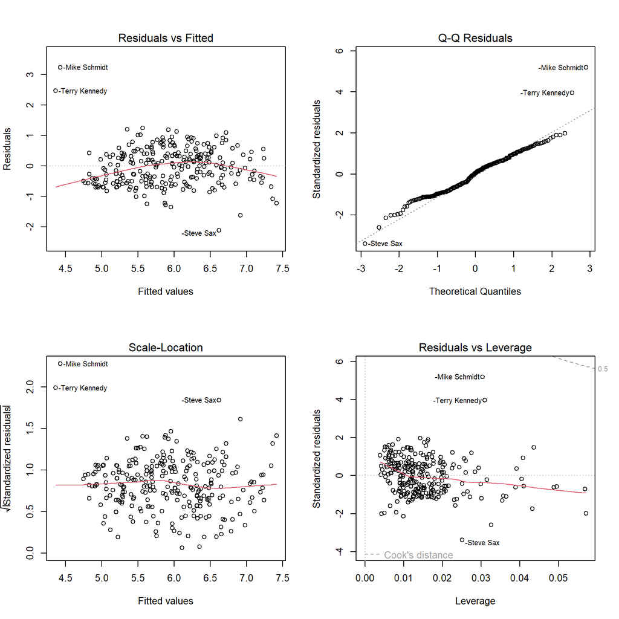

```r
par(mfrow=c(2,2))
plot(best.bic.log)
```

```r
par(mfrow=c(1,1))
```

##### 4. **Try to improve the model fitted in the previous point by (i) including all the interaction effects between the predictors and (ii) by including a quadratic component for each of the predictors (and no interaction effects).**

We consider first the models with all the interactions. All the interaction effects are significantly different to zero. However, there is a small increse in the $R^2$ statistics and the diagnostic plot show the the nonlinear pattern in the residuals is still present.

```r
best.bic.log.int <- lm(log(Salary)~Hits*Walks*Years, data=Hitters)
summary(best.bic.log.int)
```

```
##
## Call:
## lm(formula = log(Salary) ~ Hits * Walks * Years, data = Hitters)
##
## Residuals:
##      Min       1Q   Median       3Q      Max
## -2.39608 -0.40909 -0.02391  0.40472  2.18868
##
## Coefficients:
##                    Estimate Std. Error t value Pr(>|t|)
## (Intercept)       5.524e+00  3.011e-01  18.343  < 2e-16 ***
## Hits             -8.095e-03  3.219e-03  -2.515 0.012529 *
## Walks            -2.705e-02  9.484e-03  -2.853 0.004693 **
## Years            -2.235e-02  3.900e-02  -0.573 0.566978
## Hits:Walks        3.351e-04  7.857e-05   4.265 2.82e-05 ***
## Hits:Years        1.436e-03  4.159e-04   3.454 0.000647 ***
## Walks:Years       2.499e-03  1.161e-03   2.153 0.032277 *
## Hits:Walks:Years -2.749e-05  9.951e-06  -2.763 0.006153 **
## ---
## Signif. codes:  0 '***' 0.001 '**' 0.01 '*' 0.05 '.' 0.1 ' ' 1
##
## Residual standard error: 0.6076 on 255 degrees of freedom
## Multiple R-squared:  0.5456, Adjusted R-squared:  0.5331
## F-statistic: 43.74 on 7 and 255 DF,  p-value: < 2.2e-16
```

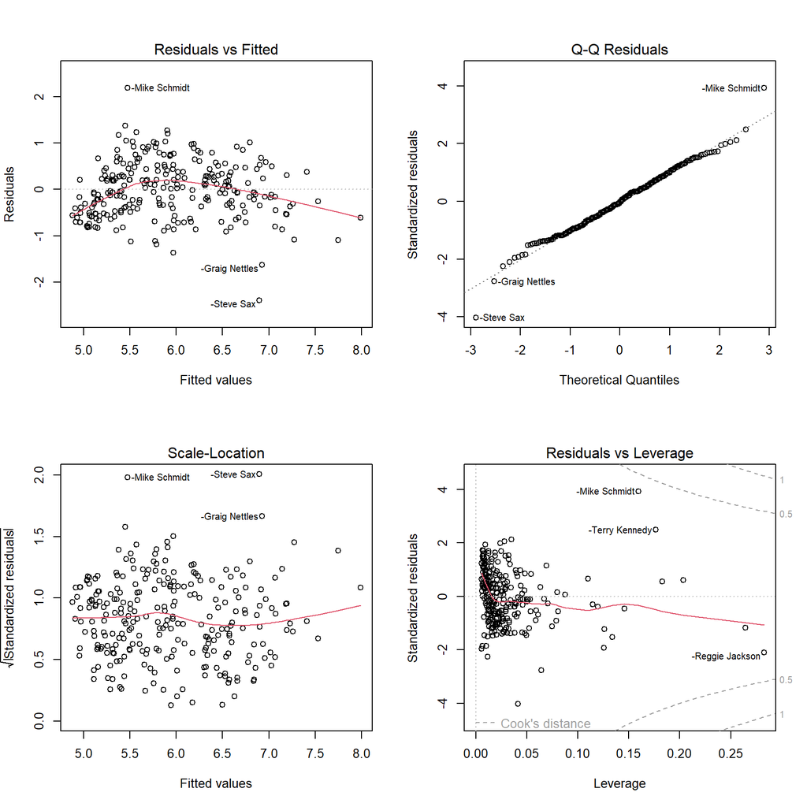

```r
par(mfrow=c(2,2))
plot(best.bic.log.int)
```

```r
par(mfrow=c(1,1))
```

We consider now the model with the quadratic components.

```r
best.bic.log.poly <-lm(log(Salary)~poly(Hits, 2)+poly(Walks, 2)+poly(Years, 2), data=Hitters)
summary(best.bic.log.poly)
```

```
##
## Call:
## lm(formula = log(Salary) ~ poly(Hits, 2) + poly(Walks, 2) + poly(Years,
##     2), data = Hitters)
##
## Residuals:
##      Min       1Q   Median       3Q      Max
## -2.47820 -0.29570 -0.02948  0.31953  2.76416
##
## Coefficients:
##                 Estimate Std. Error t value Pr(>|t|)
## (Intercept)      5.92722    0.03366 176.076  < 2e-16 ***
## poly(Hits, 2)1   3.93764    0.73884   5.330 2.16e-07 ***
## poly(Hits, 2)2   1.78147    0.59889   2.975 0.003214 **
## poly(Walks, 2)1  2.68032    0.73281   3.658 0.000309 ***
## poly(Walks, 2)2  0.98497    0.59946   1.643 0.101589
## poly(Years, 2)1  7.41905    0.55353  13.403  < 2e-16 ***
## poly(Years, 2)2 -5.03032    0.55948  -8.991  < 2e-16 ***
## ---
## Signif. codes:  0 '***' 0.001 '**' 0.01 '*' 0.05 '.' 0.1 ' ' 1
##
## Residual standard error: 0.5459 on 256 degrees of freedom
## Multiple R-squared:  0.6317, Adjusted R-squared:  0.6231
## F-statistic: 73.18 on 6 and 256 DF,  p-value: < 2.2e-16
```

The quadratic component of `Walks` is not significant and thus we remove it.

```r
best.bic.log.poly <-lm(log(Salary)~poly(Hits, 2)+Walks+poly(Years, 2), data=Hitters)
summary(best.bic.log.poly)
```

```
##
## Call:
## lm(formula = log(Salary) ~ poly(Hits, 2) + Walks + poly(Years,
##     2), data = Hitters)
##
## Residuals:
##      Min       1Q   Median       3Q      Max
## -2.53301 -0.28497 -0.02085  0.32311  2.85294
##
## Coefficients:
##                  Estimate Std. Error t value Pr(>|t|)
## (Intercept)      5.578146   0.089790  62.125  < 2e-16 ***
## poly(Hits, 2)1   3.532907   0.698866   5.055 8.18e-07 ***
## poly(Hits, 2)2   2.081666   0.572222   3.638 0.000332 ***
## Walks            0.008490   0.002024   4.196 3.75e-05 ***
## poly(Years, 2)1  7.450903   0.555015  13.425  < 2e-16 ***
## poly(Years, 2)2 -5.006432   0.561140  -8.922  < 2e-16 ***
## ---
## Signif. codes:  0 '***' 0.001 '**' 0.01 '*' 0.05 '.' 0.1 ' ' 1
##
## Residual standard error: 0.5477 on 257 degrees of freedom
## Multiple R-squared:  0.6278, Adjusted R-squared:  0.6206
## F-statistic:  86.7 on 5 and 257 DF,  p-value: < 2.2e-16
```

We see a considerable improvement of the $R^2$ statistic and the residuals are now satisfying, a part from some outliers that should be analysed in more details.

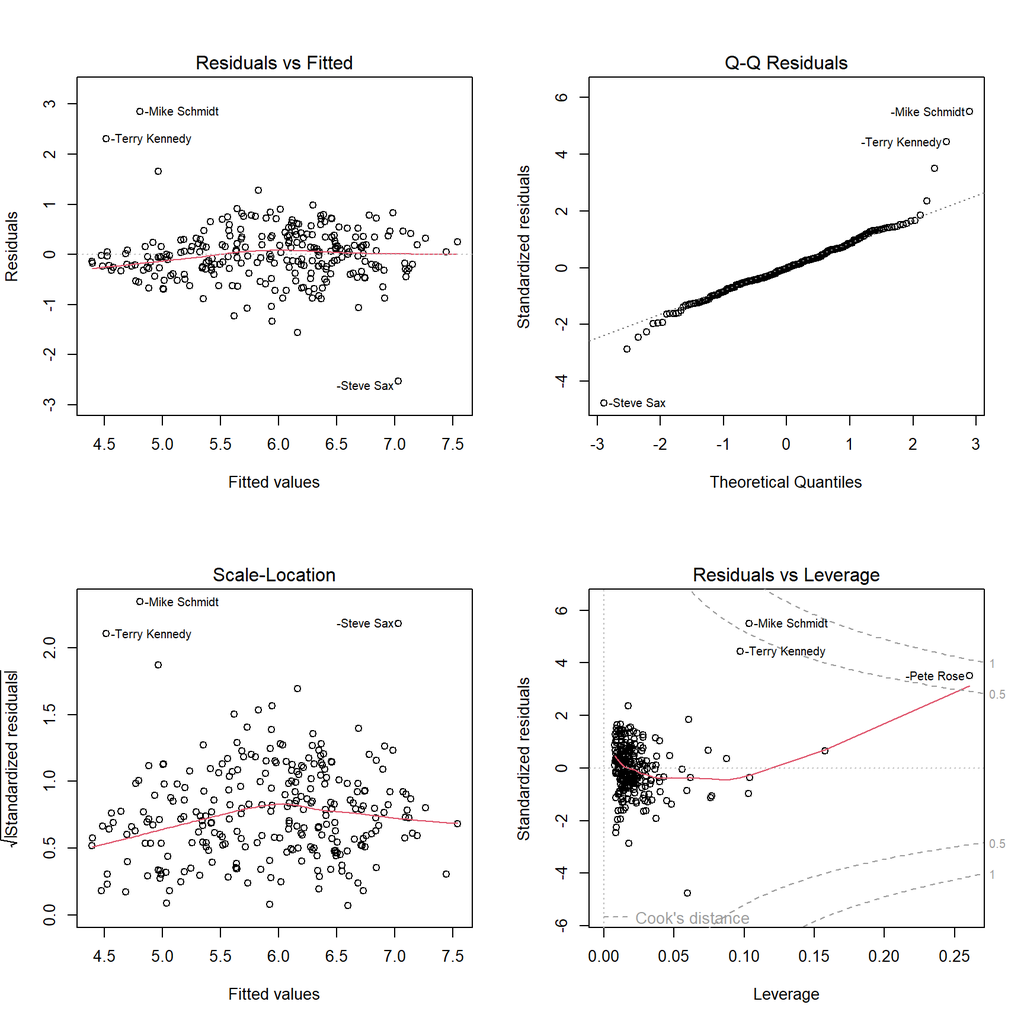

```r
par(mfrow=c(2,2))
plot(best.bic.log.poly)
```

```r
par(mfrow=c(1,1))
```

##### 5. **Apply Best Subset Selection and choose among models using LOOCV and 10-fold Cross-Validation**

We first apply again the function `regsubset()` and load the package `boot`. Recall that this package requires that the linear model is fitted with the function `glm()`.

```r
regfit.full <- regsubsets(Salary ~ ., data = Hitters, nvmax = 19)
reg.summary <- summary(regfit.full)
library(boot)
```

then we implement a loop to apply K-fold cross validation to all the 19 selected models. We first consider K=10, and it is interesting to specify different random seed values and see how the result changes.

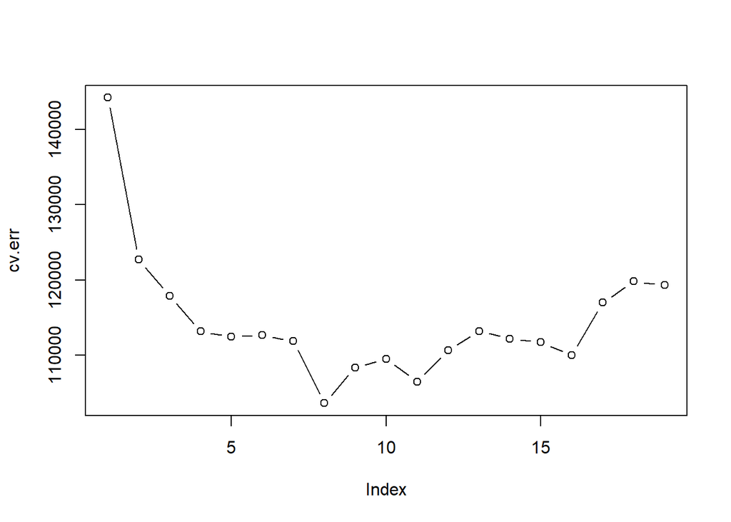

```r
K <- 10

# try to change this value
set.seed(123)

cv.err <- rep(0, length=19)
for(i in 1:19){
  mod.formula <- make.formula("Salary", names(Hitters), reg.summary, i)
  lm.fit <- glm(mod.formula, data=Hitters)
  cv.err[i] <- cv.glm(Hitters, lm.fit, K=10)$delta[[1]]
}

plot(cv.err, type="b")
```

```r
# selected model
i <- which.min(cv.err)
i
```

```
## [1] 8
```

```r
coef(regfit.full, i)
```

```
##  (Intercept)        AtBat         Hits        Walks       CHmRun        CRuns
##  130.9691577   -2.1731903    7.3582935    6.0037597    1.2339718    0.9651349
##       CWalks    DivisionW      PutOuts
##   -0.8323788 -117.9657795    0.2908431
```

The same code can be used to implement LOOCV by either setting K equal to the sample size or simply by omitting to pass K as an argument of `cv.glm()`. Note that LOOCV is computationally more demanding and, for this reason, we have included the option `eval=TRUE` in the chunk, this can be turned to `FALSE` to obtain that the chunk is not executed.

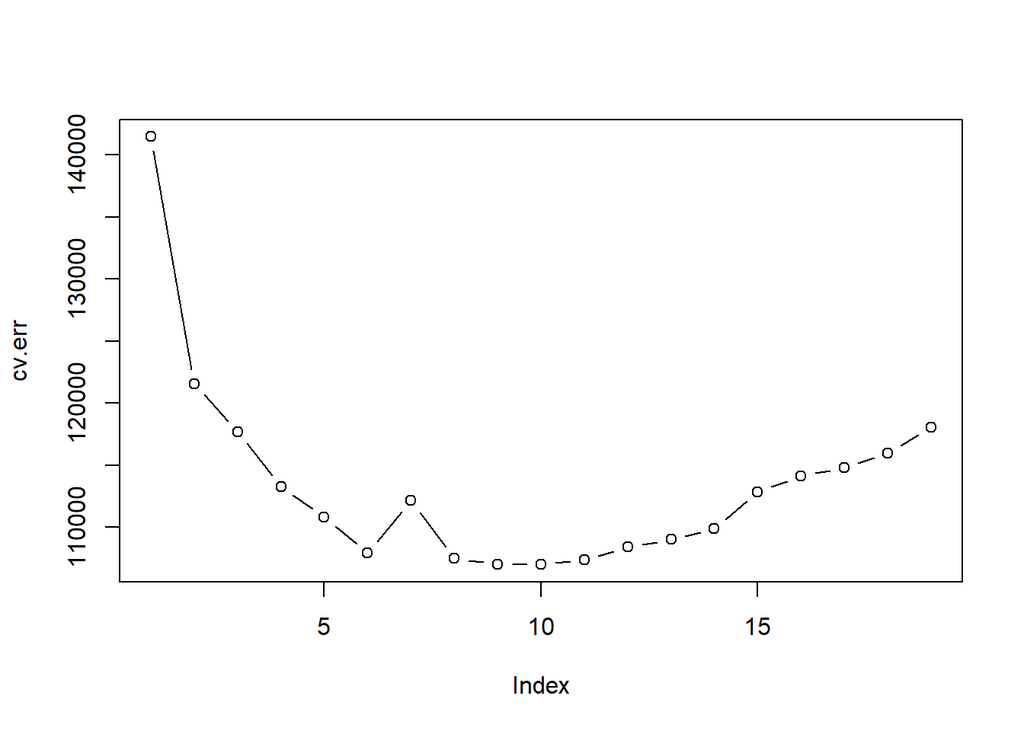

```r
cv.err <- rep(0, length=19)
for(i in 1:19){
  mod.formula <- make.formula("Salary", names(Hitters), reg.summary, i)
  lm.fit <- glm(mod.formula, data=Hitters)
  cv.err[i] <- cv.glm(Hitters, lm.fit)$delta[[1]]
}

plot(cv.err, type="b")
```

```r
# selected model
i <- which.min(cv.err)
i
```

```
## [1] 10
```

```r
coef(regfit.full, i)
```

```
##  (Intercept)        AtBat         Hits        Walks       CAtBat        CRuns
##  162.5354420   -2.1686501    6.9180175    5.7732246   -0.1300798    1.4082490
##         CRBI       CWalks    DivisionW      PutOuts      Assists
##    0.7743122   -0.8308264 -112.3800575    0.2973726    0.2831680
```